# Exposure Therapy or Cognitive Restructuring for Statistics Anxiety?

Chen Man Hin

2026-04-17

### Libraries

To investigate statistics anxiety, all analyses were conducted in R using the bootnet package for network estimation and the igraph package for network visualisation, analysis and simulation.

```r
library(igraph)
library(bootnet) # to compute partial correlation matrix
library(tidyverse) # for data wrangling
library(psych) # for internal consistency
```

### Data

The 51-item STARS was partitioned into its two theoretically established domains: the affective sub-domain (items 1-23) and cognitive sub-domain (items 24-51). Partial correlation networks were estimated for both sub-networks, as well as the global network, and subsequently converted into undirected, weighted igraph objects for analysis.

```r
# load the data
data <- read.csv('stars-data_132.csv', header = T) |>
  filter(ResponseId != "R_4hymyKs8w9S3T3T") # excluded due to missing data
# split into sub-networks and full network
affective <- data |> select(item_1:item_23) # affective sub-network
cognitive <- data |> select(item_24:item_51) # cognitive sub-network
all <- data |> select(item_1:item_51)  # full network
# create partial correlation matrix for each sub-network and full network
net_affective <- estimateNetwork(affective, default = "pcor",
                                threshold = 'sig') # affective partial correlation matrix
```

```
## Estimating Network. Using package::function:
##   - qgraph::qgraph(..., graph = 'pcor') for network computation
##   - psych::corr.p for significance thresholding
```

```r
net_cognitive <- estimateNetwork(cognitive, default = "pcor",
                                threshold = 'sig') # cognitive partial correlation matrix
```

```
## Estimating Network. Using package::function:
##   - qgraph::qgraph(..., graph = 'pcor') for network computation
##   - psych::corr.p for significance thresholding
```

```r
net_g <- estimateNetwork(all, default = "pcor",
                         threshold = 'sig') # full network
```

```
## Estimating Network. Using package::function:
##   - qgraph::qgraph(..., graph = 'pcor') for network computation
##   - psych::corr.p for significance thresholding
```

```r
# convert all to igraph objects for analysis
g_affective <- graph_from_adjacency_matrix(abs(net_affective$graph),
                                           mode="undirected", weighted = TRUE)
g_cognitive <- graph_from_adjacency_matrix(abs(net_cognitive$graph),
                                           mode="undirected", weighted = TRUE)
g <- graph_from_adjacency_matrix(abs(net_g$graph),
                                 mode="undirected", weighted = TRUE)
summary(g_affective)
```

```
## IGRAPH 5e152ae UNW- 23 40 --
## + attr: name (v/c), weight (e/n)
```

```r
summary(g_cognitive)
```

```
## IGRAPH 5e164c6 UNW- 28 43 --
## + attr: name (v/c), weight (e/n)
```

```r
# internal consistency check
cat("\n--- RELIABILITY: AFFECTIVE SUB-SCALE ---\n")
```

```
##
## --- RELIABILITY: AFFECTIVE SUB-SCALE ---
```

```r
alpha_affective <- psych::alpha(affective) # Cronbach alpha value for affective
print(alpha_affective$total$raw_alpha)
```

```
## [1] 0.9219761
```

```r
cat("\n--- RELIABILITY: COGNITIVE SUB-SCALE ---\n")
```

```
##
## --- RELIABILITY: COGNITIVE SUB-SCALE ---
```

```r
alpha_cognitive <- psych::alpha(cognitive) # Cronbach alpha value for cognitive
print(alpha_cognitive$total$raw_alpha)
```

```
## [1] 0.9520611
```

```r
cat("\n--- RELIABILITY: FULL NETWORK ---\n")
```

```
##
## --- RELIABILITY: FULL NETWORK ---
```

```r
alpha_network <- psych::alpha(all) # Cronbach alpha value for cognitive
print(alpha_network$total$raw_alpha)
```

```
## [1] 0.9531074
```

### Network Visualisation

To visually inspect the structural differences between the sub-domains, the networks were plotted below.

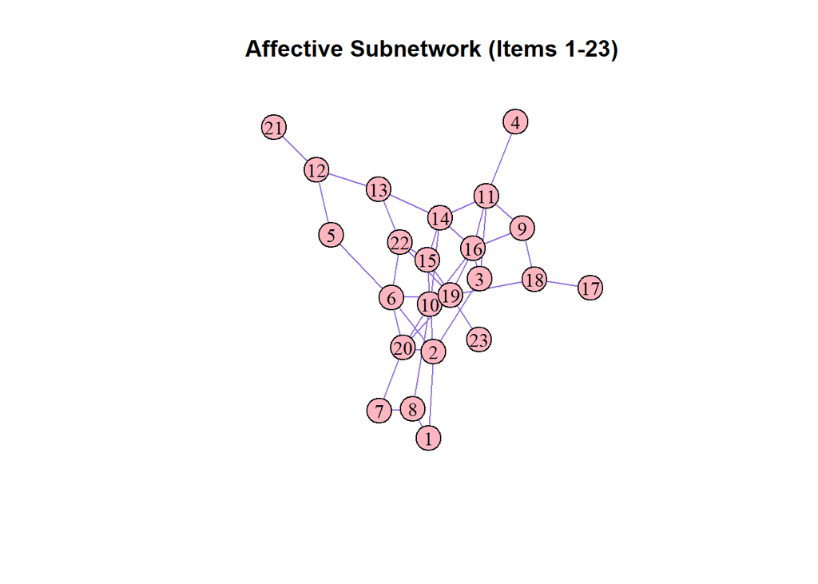

```r
# remove 'i_' and 'it_' for presentation and readability
V(g_affective)$label <- gsub("^(i_|it_)", "", V(g_affective)$name)
V(g_cognitive)$label <- gsub("^(i_|it_)", "", V(g_cognitive)$name)

# plot for affective sub-network
plot(g_affective,
    vertex.color = "lightpink",
    edge.color = "mediumpurple",
    vertex.label.color = "black",
    vertex.size = 16,
    vertex.shape = 'circle',
    main = "Affective Subnetwork (Items 1-23)")
```

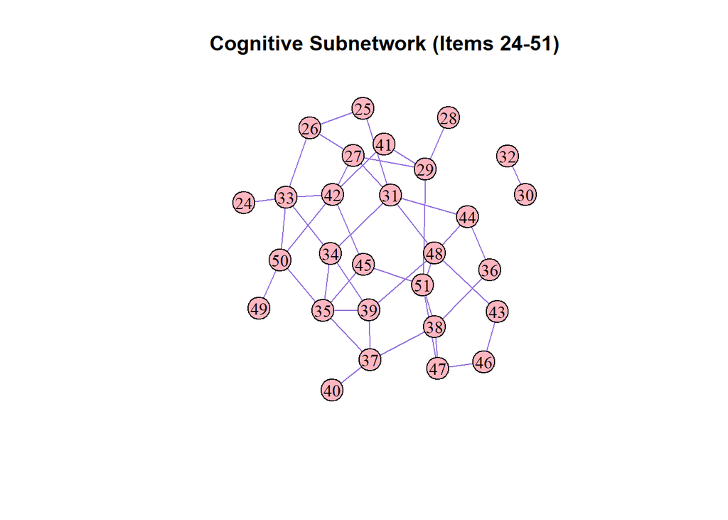

```r
# plot for cognitive sub-network
plot(g_cognitive,
    vertex.color = "lightpink",
    edge.color = "mediumpurple",
    vertex.label.color = "black",
    vertex.size = 16,
    vertex.shape = 'circle',
    main = "Cognitive Subnetwork (Items 24-51)")
```

## Hypothesis 1: Internal Cohesion VS Path Efficiency

**Does the cognitive sub-network exhibit greater internal cohesion, whereas the affective sub-system facilitate greater path efficiency?**

*Internal cohesion* was tested by comparing macro-level metrics including average node strength, edge density, transitivity and degree assortativity; which mathematically assesses the presence of triads in the sub-network. The cognitive components of statistics anxiety are thus expected to exhibit significantly greater values for internal cohesion, presenting structurally as a clustered core of closed triangles, than affective items.

*Path efficiency* was evaluated using the Average Shortest Path Length (ASPL), where shorter paths indicate greater transmission efficiency. Accordingly, the affective sub-network is expected to exhibit a shorter ASPL than the cognitive sub-network, facilitating faster contagion.

### Macro-Level Analysis: Internal Cohesion

```r
cat("\n--- INTERNAL COHESION ---\n")
```

```
##
## --- INTERNAL COHESION ---
```

```r
# Affective Sub-Network
mean(strength(g_affective)) # average node strength
```

```
## [1] 0.9619523
```

```r
edge_density(g_affective) # density
```

```
## [1] 0.1581028
```

```r
transitivity(g_affective, type = "global") # global clustering (transitivity)
```

```
## [1] 0.2238806
```

```r
assortativity_degree(g_affective) # degree assortativity
```

```
## [1] 0.07933399
```

```r
# Cognitive Sub-Network
mean(strength(g_cognitive)) # average node strength
```

```
## [1] 0.8172851
```

```r
edge_density(g_cognitive) # density
```

```
## [1] 0.1137566
```

```r
transitivity(g_cognitive, type = "global") # global clustering (transitivity)
```

```
## [1] 0.1260504
```

```r
assortativity_degree(g_cognitive) # degree assortativity
```

```
## [1] 0.05594901
```

### Macro-Level Analysis: Path Efficiency

```r
cat("\n--- PATH EFFICIENCY ---\n")
```

```
##
## --- PATH EFFICIENCY ---
```

```r
# Affective Sub-Network
mean_distance(g_affective, weights = NA) # average shortest path length
```

```
## [1] 2.648221
```

```r
# Cognitive Sub-Network
mean_distance(g_cognitive, weights = NA) # average shortest path length
```

```
## [1] 2.785276
```

## Hypothesis 2: Network Degradation Simulation

**Is structural disintegration, measured by decrease in global edge density, more efficacious from targeted “keystone” symptom deactivation than random symptom alleviation?**

*Keystone symptoms* were defined as the top five nodes possessing the highest eigenvector centrality within the global network. To ensure fair comparison, five random nodes were deactivated.

```r
cat("\n--- DEGRADATION SIMULATION (REMOVING 5 NODES) ---\n")
```

```
##
## --- DEGRADATION SIMULATION (REMOVING 5 NODES) ---
```

```r
baseline_density <- edge_density(g)
print(baseline_density)
```

```
## [1] 0.09960784
```

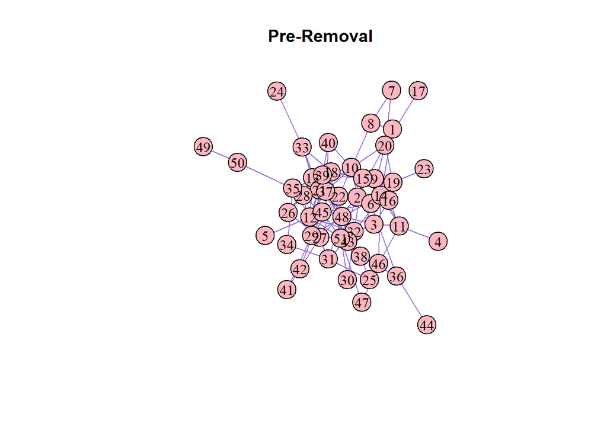

```r
# Plot Network Before Degradation
V(g)$label <- gsub("^(i_|it_)", "", V(g)$name) # remove 'i_' and 'it_' for presentation and readability
plot(g,
    vertex.color = "lightpink",
    edge.color = "mediumpurple",
    vertex.label.color = "black",
    vertex.size = 16,
    vertex.shape = 'circle',
    main = "Pre-Removal")
```

```r
# Simulation A: Targeted Removal (Highest Strength)
ec <- eigen_centrality(g)$vector
targeted <- names(sort(ec,
                       decreasing = TRUE)[1:5]) # identify top 5 nodes with highest ec
g_targeted <- delete_vertices(g, targeted) # deactivate these nodes
density_targeted <- edge_density(g_targeted) # new density
difference_targeted <- baseline_density - density_targeted
print(density_targeted)
```

```
## [1] 0.07826087
```

```r
print(difference_targeted)
```

```
## [1] 0.02134697
```

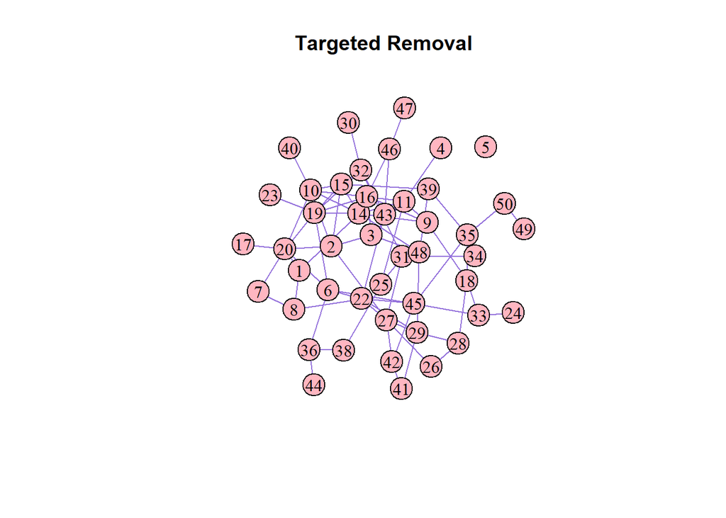

```r
# Plot Targeted Degradation Network
V(g_targeted)$label <- gsub("^(i_|it_)", "", V(g_targeted)$name) # remove 'i_' and 'it_' for presentation and readability
plot(g_targeted,
    vertex.color = "lightpink",
    edge.color = "mediumpurple",
    vertex.label.color = "black",
    vertex.size = 16,
    vertex.shape = 'circle',
    main = "Targeted Removal")
```

```r
# Simulation B: Random Removal
set.seed(1)
random <- V(g)$name[sample(1:gorder(g), 5, replace = FALSE)] # random 5 nodes
g_random <- delete_vertices(g, random) # deactivate these nodes
density_random <- edge_density(g_random) # new density
difference_random <- baseline_density - density_random
print(density_random)
```

```
## [1] 0.1091787
```

```r
print(difference_random)
```

```
## [1] -0.009570901
```

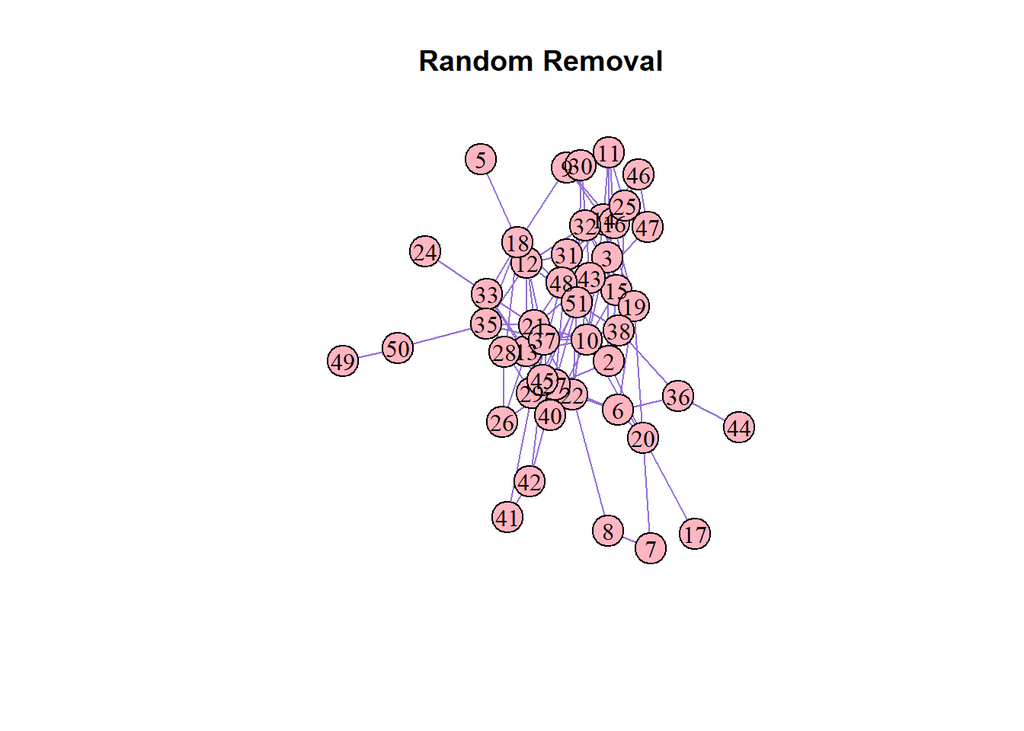

```r
# Plot Random Degradation Network
V(g_random)$label <- gsub("^(i_|it_)", "", V(g_random)$name) # remove 'i_' and 'it_' for presentation and readability
plot(g_random,
    vertex.color = "lightpink",
    edge.color = "mediumpurple",
    vertex.label.color = "black",
    vertex.size = 16,
    vertex.shape = 'circle',
    main = "Random Removal")
```

### Exploratory Analysis: Micro-Level Symptom Profiling

To translate these macro-level findings into actionable clinical targets, a post-hoc micro-level analysis was performed. Node strength was computed to identify the primary drivers (hubs) of anxiety within each domain, and betweenness centrality was calculated to locate the critical bridges across the network.

```r
# Node Strength (Central Hubs)
strength_affective <- strength(g_affective)
strength_cognitive <- strength(g_cognitive)
# Betweenness Centrality (Structural Bridges)
betweenness_affective <- betweenness(g_affective, directed = FALSE,
                                     weights = 1/abs(E(g_affective)$weight))
betweenness_cognitive <- betweenness(g_cognitive, directed = FALSE,
                                     weights = 1/abs(E(g_cognitive)$weight))

# Top Three of Affective Sub-network
top_affective <- head(sort(strength_affective, decreasing = TRUE), 3)
print(top_affective)
```

```
##     i_19     i_16     i_10
## 1.972787 1.869824 1.695831
```

```r
top_b_affective <- head(sort(betweenness_affective, decreasing = TRUE), 3)
print(top_b_affective)
```

```
## i_19 i_10 i_14
##   58   45   44
```

```r
# Top Three of Cognitive Sub-network
top_cognitive <- head(sort(strength_cognitive, decreasing = TRUE), 3)
print(top_cognitive)
```

```
##     i_42     i_51     i_38
## 1.462530 1.462072 1.341585
```

```r
top_b_cognitive <- head(sort(betweenness_cognitive, decreasing = TRUE), 3)
print(top_b_cognitive)
```

```
## i_31 i_51 i_35
##   60   56   47
```

```r
# Simulate Removal of Top Three Central Hubs for Both Affective and Cognitive Sub-Networks
cat("\n--- DEGRADATION: REMOVING TOP 3 STRENGTH HUBS ---\n")
```

```
##
## --- DEGRADATION: REMOVING TOP 3 STRENGTH HUBS ---
```

```r
# Affective Sub-network
edge_density(g_affective)
```

```
## [1] 0.1581028
```

```r
hubs_affective <- names(top_affective)
degrade_affective <- delete_vertices(g_affective, hubs_affective) # to remove top 3
print(edge_density(degrade_affective))
```

```
## [1] 0.1210526
```

```r
print(edge_density(g_affective)-edge_density(degrade_affective))
```

```
## [1] 0.03705014
```

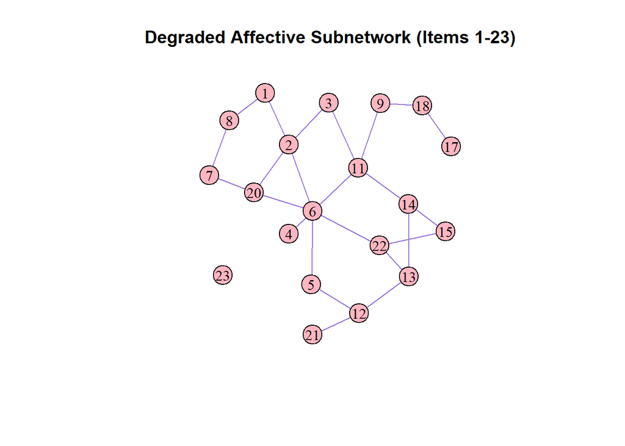

```r
# plot for degraded affective sub-network
plot(degrade_affective,
    vertex.color = "lightpink",
    edge.color = "mediumpurple",
    vertex.label.color = "black",
    vertex.size = 16,
    vertex.shape = 'circle',
    main = "Degraded Affective Subnetwork (Items 1-23)")
```

```r
# Cognitive Sub-network
edge_density(g_cognitive)
```

```
## [1] 0.1137566
```

```r
hubs_cognitive <- names(top_cognitive)
degrade_cognitive <- delete_vertices(g_cognitive, hubs_cognitive)
print(edge_density(degrade_cognitive))
```

```
## [1] 0.1
```

```r
print(edge_density(g_cognitive)-edge_density(degrade_cognitive))
```

```
## [1] 0.01375661
```

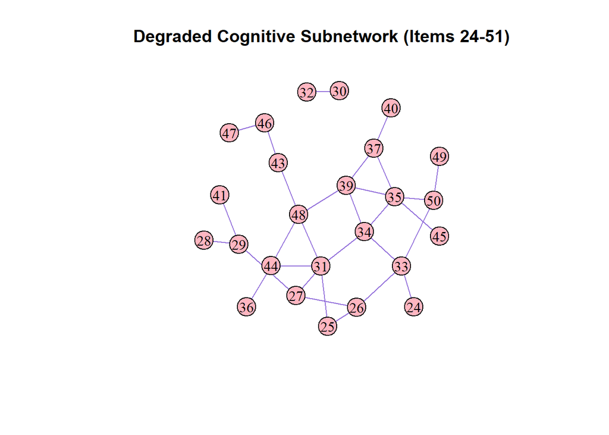

```r
plot(degrade_cognitive,
    vertex.color = "lightpink",
    edge.color = "mediumpurple",
    vertex.label.color = "black",
    vertex.size = 16,
    vertex.shape = 'circle',
    main = "Degraded Cognitive Subnetwork (Items 24-51)")
```